# Kvaliteta vina (Wine Quality)

Mateja Žunec, Aleksandar Babić

2024-05-05

## Ukratko o promatranom skupu podataka

U ovom projektu analizirat će se dva skupa podataka za crveno i bijelo vino portugalskog proizvođača **Vinho Verde**. Zbog problema s privatnošću prikazane su samo fizikalno-kemijske i senzorne varijable (npr. nema podataka o vrstama grožda, marki vina i prodajnoj cijeni).

- Broj zapisa za crno vino: 1599
- Broj zapisa za bijelo vino: 4898
- Broj atributa: 12

Vrijednosti atributa koje nedostaju: Nema

## Učitavanje podataka

```r
winequality_red <- read_delim("winequality-red.csv", delim = ";")
winequality_white <- read_delim("winequality-white.csv", delim = ";")
```

## Sažetak statističkih informacija o svakoj varijabli

```r
summary(winequality_red)
```

```
##  fixed acidity   volatile acidity  citric acid    residual sugar
##  Min.   : 4.60   Min.   :0.1200   Min.   :0.000   Min.   : 0.900
##  1st Qu.: 7.10   1st Qu.:0.3900   1st Qu.:0.090   1st Qu.: 1.900
##  Median : 7.90   Median :0.5200   Median :0.260   Median : 2.200
##  Mean   : 8.32   Mean   :0.5278   Mean   :0.271   Mean   : 2.539
##  3rd Qu.: 9.20   3rd Qu.:0.6400   3rd Qu.:0.420   3rd Qu.: 2.600
##  Max.   :15.90   Max.   :1.5800   Max.   :1.000   Max.   :15.500
##    chlorides       free sulfur dioxide total sulfur dioxide    density
##  Min.   :0.01200   Min.   : 1.00       Min.   :  6.00       Min.   :0.9901
##  1st Qu.:0.07000   1st Qu.: 7.00       1st Qu.: 22.00       1st Qu.:0.9956
##  Median :0.07900   Median :14.00       Median : 38.00       Median :0.9968
##  Mean   :0.08747   Mean   :15.87       Mean   : 46.47       Mean   :0.9967
##  3rd Qu.:0.09000   3rd Qu.:21.00       3rd Qu.: 62.00       3rd Qu.:0.9978
##  Max.   :0.61100   Max.   :72.00       Max.   :289.00       Max.   :1.0037
##        pH          sulphates         alcohol         quality
##  Min.   :2.740   Min.   :0.3300   Min.   : 8.40   Min.   :3.000
##  1st Qu.:3.210   1st Qu.:0.5500   1st Qu.: 9.50   1st Qu.:5.000
##  Median :3.310   Median :0.6200   Median :10.20   Median :6.000
##  Mean   :3.311   Mean   :0.6581   Mean   :10.42   Mean   :5.636
##  3rd Qu.:3.400   3rd Qu.:0.7300   3rd Qu.:11.10   3rd Qu.:6.000
##  Max.   :4.010   Max.   :2.0000   Max.   :14.90   Max.   :8.000
```

```r
summary(winequality_white)
```

```
##  fixed acidity    volatile acidity  citric acid     residual sugar
##  Min.   : 3.800   Min.   :0.0800   Min.   :0.0000   Min.   : 0.600
##  1st Qu.: 6.300   1st Qu.:0.2100   1st Qu.:0.2700   1st Qu.: 1.700
##  Median : 6.800   Median :0.2600   Median :0.3200   Median : 5.200
##  Mean   : 6.855   Mean   :0.2782   Mean   :0.3342   Mean   : 6.391
##  3rd Qu.: 7.300   3rd Qu.:0.3200   3rd Qu.:0.3900   3rd Qu.: 9.900
##  Max.   :14.200   Max.   :1.1000   Max.   :1.6600   Max.   :65.800
##    chlorides       free sulfur dioxide total sulfur dioxide    density
##  Min.   :0.00900   Min.   :  2.00      Min.   :  9.0        Min.   :0.9871
##  1st Qu.:0.03600   1st Qu.: 23.00      1st Qu.:108.0        1st Qu.:0.9917
##  Median :0.04300   Median : 34.00      Median :134.0        Median :0.9937
##  Mean   :0.04577   Mean   : 35.31      Mean   :138.4        Mean   :0.9940
##  3rd Qu.:0.05000   3rd Qu.: 46.00      3rd Qu.:167.0        3rd Qu.:0.9961
##  Max.   :0.34600   Max.   :289.00      Max.   :440.0        Max.   :1.0390
##        pH          sulphates         alcohol         quality
##  Min.   :2.720   Min.   :0.2200   Min.   : 8.00   Min.   :3.000
##  1st Qu.:3.090   1st Qu.:0.4100   1st Qu.: 9.50   1st Qu.:5.000
##  Median :3.180   Median :0.4700   Median :10.40   Median :6.000
##  Mean   :3.188   Mean   :0.4898   Mean   :10.51   Mean   :5.878
##  3rd Qu.:3.280   3rd Qu.:0.5500   3rd Qu.:11.40   3rd Qu.:6.000
##  Max.   :3.820   Max.   :1.0800   Max.   :14.20   Max.   :9.000
```

## Struktura varijabli

```r
#Struktura objekta, tip svake varijable(u ovom slučaju su sve numeričke, prikaz prvih nekoliko vrijednosti, pregled strukture)
#Sve su kvantitativne numeričke varijable.
str(winequality_red)
```

```
## spc_tbl_ [1,599 × 12] (S3: spec_tbl_df/tbl_df/tbl/data.frame)
##  $ fixed acidity       : num [1:1599] 7.4 7.8 7.8 11.2 7.4 7.4 7.9 7.3 7.8 7.5 ...
##  $ volatile acidity    : num [1:1599] 0.7 0.88 0.76 0.28 0.7 0.66 0.6 0.65 0.58 0.5 ...
##  $ citric acid         : num [1:1599] 0 0 0.04 0.56 0 0 0.06 0 0.02 0.36 ...
##  $ residual sugar      : num [1:1599] 1.9 2.6 2.3 1.9 1.9 1.8 1.6 1.2 2 6.1 ...
##  $ chlorides           : num [1:1599] 0.076 0.098 0.092 0.075 0.076 0.075 0.069 0.065 0.073 0.071 ...
##  $ free sulfur dioxide : num [1:1599] 11 25 15 17 11 13 15 15 9 17 ...
##  $ total sulfur dioxide: num [1:1599] 34 67 54 60 34 40 59 21 18 102 ...
##  $ density             : num [1:1599] 0.998 0.997 0.997 0.998 0.998 ...
##  $ pH                  : num [1:1599] 3.51 3.2 3.26 3.16 3.51 3.51 3.3 3.39 3.36 3.35 ...
##  $ sulphates           : num [1:1599] 0.56 0.68 0.65 0.58 0.56 0.56 0.46 0.47 0.57 0.8 ...
##  $ alcohol             : num [1:1599] 9.4 9.8 9.8 9.8 9.4 9.4 9.4 10 9.5 10.5 ...
##  $ quality             : num [1:1599] 5 5 5 6 5 5 5 7 7 5 ...
##  - attr(*, "spec")=
##   .. cols(
##   ..   `fixed acidity` = col_double(),
##   ..   `volatile acidity` = col_double(),
##   ..   `citric acid` = col_double(),
##   ..   `residual sugar` = col_double(),
##   ..   chlorides = col_double(),
##   ..   `free sulfur dioxide` = col_double(),
##   ..   `total sulfur dioxide` = col_double(),
##   ..   density = col_double(),
##   ..   pH = col_double(),
##   ..   sulphates = col_double(),
##   ..   alcohol = col_double(),
##   ..   quality = col_double()
##   .. )
##  - attr(*, "problems")=<externalptr>
```

```r
str(winequality_white)
```

```
## spc_tbl_ [4,898 × 12] (S3: spec_tbl_df/tbl_df/tbl/data.frame)
##  $ fixed acidity       : num [1:4898] 7 6.3 8.1 7.2 7.2 8.1 6.2 7 6.3 8.1 ...
##  $ volatile acidity    : num [1:4898] 0.27 0.3 0.28 0.23 0.23 0.28 0.32 0.27 0.3 0.22 ...
##  $ citric acid         : num [1:4898] 0.36 0.34 0.4 0.32 0.32 0.4 0.16 0.36 0.34 0.43 ...
##  $ residual sugar      : num [1:4898] 20.7 1.6 6.9 8.5 8.5 6.9 7 20.7 1.6 1.5 ...
##  $ chlorides           : num [1:4898] 0.045 0.049 0.05 0.058 0.058 0.05 0.045 0.045 0.049 0.044 ...
##  $ free sulfur dioxide : num [1:4898] 45 14 30 47 47 30 30 45 14 28 ...
##  $ total sulfur dioxide: num [1:4898] 170 132 97 186 186 97 136 170 132 129 ...
##  $ density             : num [1:4898] 1.001 0.994 0.995 0.996 0.996 ...
##  $ pH                  : num [1:4898] 3 3.3 3.26 3.19 3.19 3.26 3.18 3 3.3 3.22 ...
##  $ sulphates           : num [1:4898] 0.45 0.49 0.44 0.4 0.4 0.44 0.47 0.45 0.49 0.45 ...
##  $ alcohol             : num [1:4898] 8.8 9.5 10.1 9.9 9.9 10.1 9.6 8.8 9.5 11 ...
##  $ quality             : num [1:4898] 6 6 6 6 6 6 6 6 6 6 ...
##  - attr(*, "spec")=
##   .. cols(
##   ..   `fixed acidity` = col_double(),
##   ..   `volatile acidity` = col_double(),
##   ..   `citric acid` = col_double(),
##   ..   `residual sugar` = col_double(),
##   ..   chlorides = col_double(),
##   ..   `free sulfur dioxide` = col_double(),
##   ..   `total sulfur dioxide` = col_double(),
##   ..   density = col_double(),
##   ..   pH = col_double(),
##   ..   sulphates = col_double(),
##   ..   alcohol = col_double(),
##   ..   quality = col_double()
##   .. )
##  - attr(*, "problems")=<externalptr>
```

## Provjera ima li nepotpunih vrijednosti za atribute

```r
##Provjerava ima li nepotpunih vrijednosti kod varijabla, u ovom slučaju je FALSE znači nema
any(is.na(winequality_red))
```

```
## [1] FALSE
```

```r
any(is.na(winequality_white))
```

```
## [1] FALSE
```

## Usporedba bijelog i crvenog vina na temelju nekoliko parametara

Prema summary odabrano je nekoliko varijabli koje se razlikuju po aritmetičkoj sredini između bijelog i crvenog vina i na temelju tih podataka kreirani su grafovi (barplot) koji to vizualiziraju. Za to su uzete varijable:

1. residual sugar
2. volatile acidity
3. total sulfur dioxide

Isto tako uzeta je i varijabla **quality** kod koje ne postoji značajna razlika između crvenog i bijelog vina što je isto vidljivo na grafu (barplot).

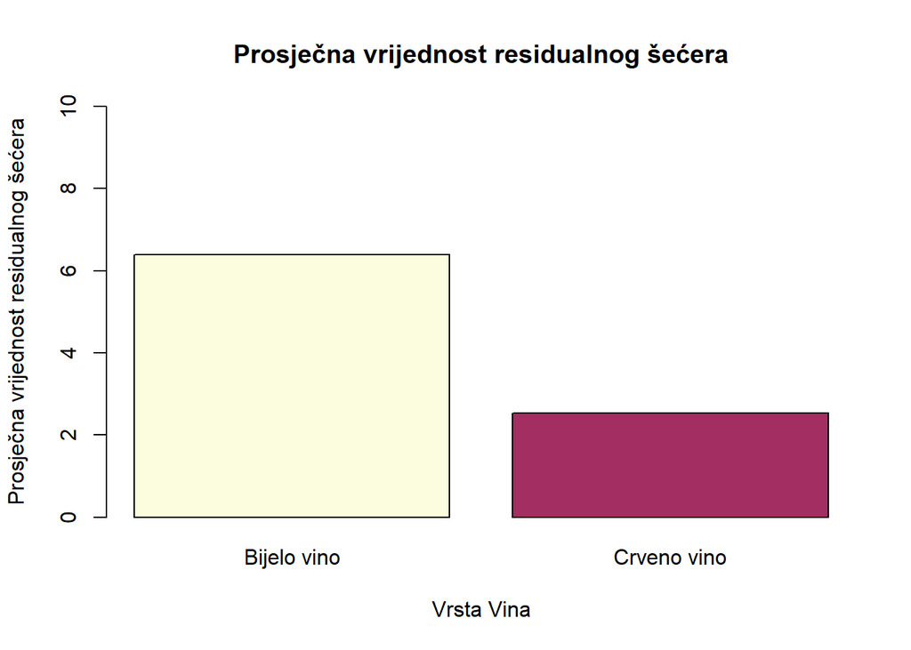

```r
# Izračun prosječnih vrijednosti udjela šećera za bijelo i crveno vino
mean_residual_sugar_white <- mean(winequality_white$`residual sugar`)
mean_residual_sugar_red <- mean(winequality_red$`residual sugar`)

# Stvaranje vektora s prosječnim vrijednostima
means <- c(mean_residual_sugar_white, mean_residual_sugar_red)

# Stvaranje vektora s imenima vrsta vina
wine_types <- c("Bijelo vino", "Crveno vino")

# Stvaranje histograma s prilagođenim skaliranjem y-osi
barplot(means, names.arg = wine_types,
        col = c("#fcfcde", "#a32e61"),
        main = "Prosječna vrijednost residualnog šećera",
        xlab = "Vrsta Vina",
        ylab = "Prosječna vrijednost residualnog šećera",
        ylim = c(0, 10))
```

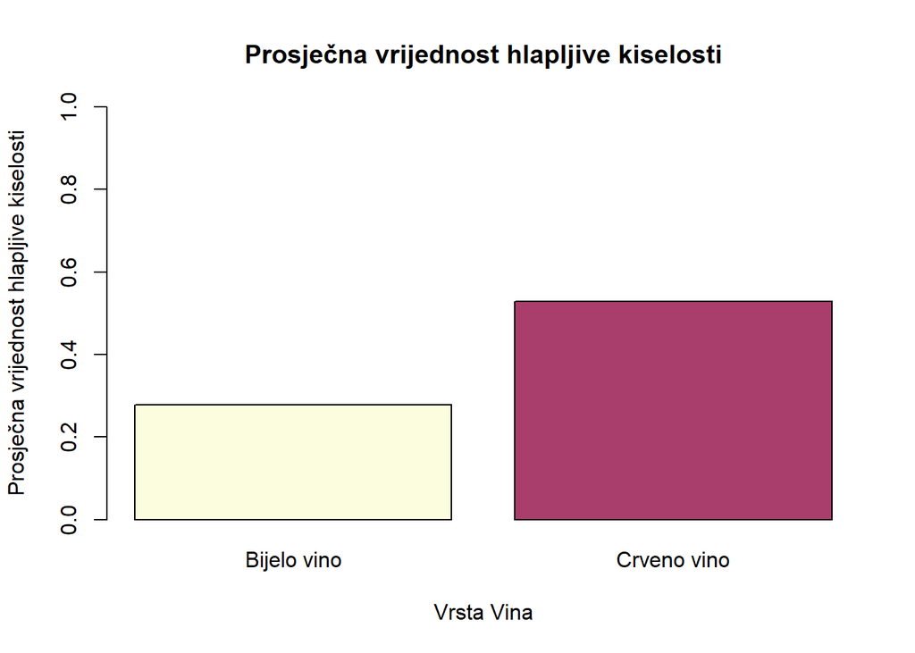

```r
# Izračun prosječnih vrijednosti hlapljive kiselosti za bijelo i crveno vino
mean_volatile_acidity_white <- mean(winequality_white$`volatile acidity`)
mean_volatile_acidity_red <- mean(winequality_red$`volatile acidity`)

# Stvaranje vektora s prosječnim vrijednostima
means_volatile_acidity <- c(mean_volatile_acidity_white, mean_volatile_acidity_red)

# Stvaranje histograma s prilagođenim skaliranjem y-osi
barplot(means_volatile_acidity, names.arg = wine_types,
        col = c("#fcfcde", "#a32e61ed"),
        main = "Prosječna vrijednost hlapljive kiselosti",
        xlab = "Vrsta Vina",
        ylab = "Prosječna vrijednost hlapljive kiselosti",
        ylim = c(0, 1))
```

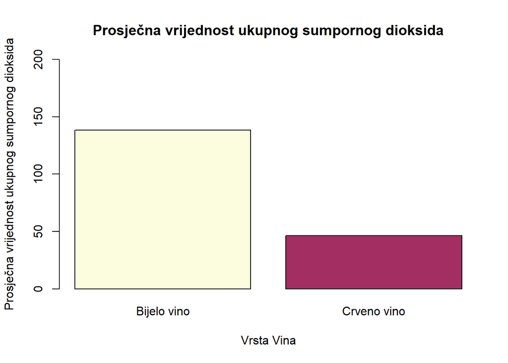

```r
# Izračun prosječnih vrijednosti ukupnog sumpornog dioksida za bijelo i crveno vino
mean_total_sulfur_dioxide_white <- mean(winequality_white$`total sulfur dioxide`)
mean_total_sulfur_dioxide_red <- mean(winequality_red$`total sulfur dioxide`)

# Stvaranje vektora s prosječnim vrijednostima
means_total_sulfur_dioxide <- c(mean_total_sulfur_dioxide_white, mean_total_sulfur_dioxide_red)

# Stvaranje histograma s prilagođenim skaliranjem y-osi
barplot(means_total_sulfur_dioxide, names.arg = wine_types,
        col = c("#fcfcde", "#a32e61"),
        main = "Prosječna vrijednost ukupnog sumpornog dioksida",
        xlab = "Vrsta Vina",
        ylab = "Prosječna vrijednost ukupnog sumpornog dioksida",
        ylim = c(0, 200))
```

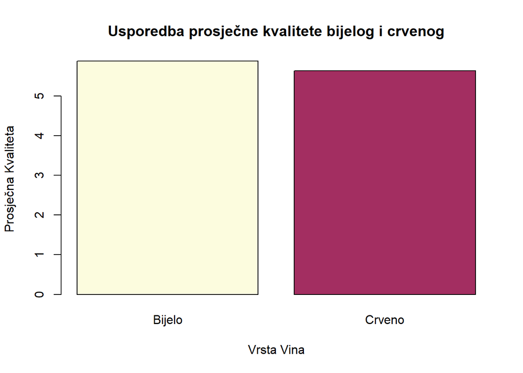

```r
# Izračunaj prosječnu vrijednost kvalitete za crveno i bijelo vino
avg_quality_red <- mean(winequality_red$quality)
avg_quality_white <- mean(winequality_white$quality)

# Definiraj vektore za kvalitetu i boje
quality <- c("Bijelo", "Crveno")
avg_quality <- c(avg_quality_white, avg_quality_red)
colors <- c("#fcfcde", "#a32e61")

# Napravi barplot
barplot(avg_quality, names.arg = quality, col = colors, main = "Usporedba prosječne kvalitete bijelog i crvenog",
        xlab = "Vrsta Vina", ylab = "Prosječna Kvaliteta")
```

Najveći broj vina ima udio od 9% alkohola kod obe vrste vina, distribucije su asimetrične.

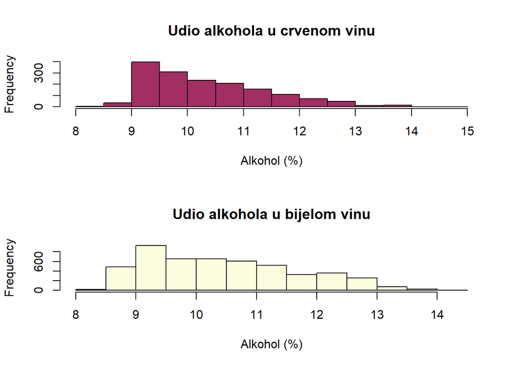

```r
par(mfrow=c(2,1))
hist(winequality_red$alcohol, main="Udio alkohola u crvenom vinu", xlab="Alkohol (%)",  col = "#a32e61")
hist(winequality_white$alcohol, main="Udio alkohola u bijelom vinu", xlab="Alkohol (%)", col="#fcfcde")
```

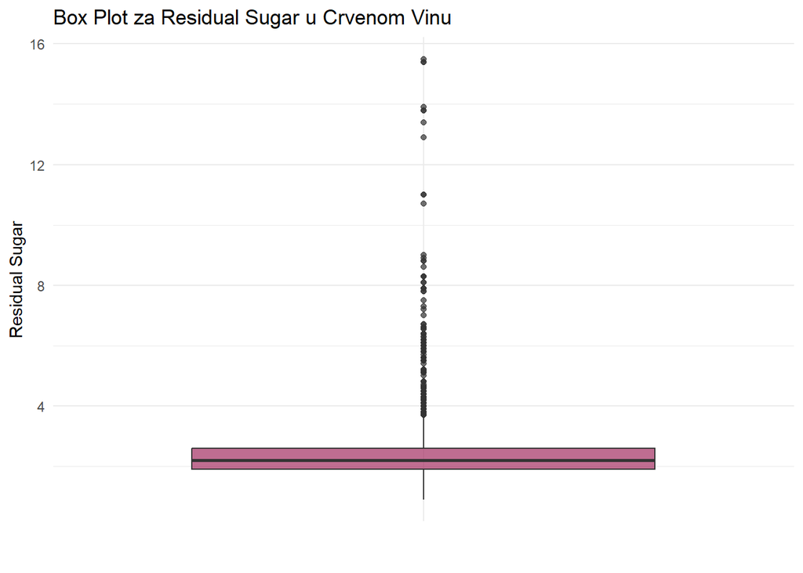

```r
# Izračun prosječnih vrijednosti udjela šećera za bijelo i crveno vino
mean_residual_sugar_white <- mean(winequality_white$`residual sugar`)
mean_residual_sugar_red <- mean(winequality_red$`residual sugar`)

# Stvaranje vektora s prosječnim vrijednostima
means <- c(mean_residual_sugar_white, mean_residual_sugar_red)

# Stvaranje vektora s imenima vrsta vina
wine_types <- c("White Wine", "Red Wine")

# Box plot za crveno vino
boxplot_red <- ggplot(data = winequality_red, aes(x = "", y = `residual sugar`)) +
  geom_boxplot(fill = "#a32e61", alpha = 0.7) +
  labs(title = "Box Plot za Residual Sugar u Crvenom Vinu",
       x = "",
       y = "Residual Sugar") +
  theme_minimal()

# Box plot za bijelo vino
boxplot_white <- ggplot(data = winequality_white, aes(x = "", y = `residual sugar`)) +
  geom_boxplot(fill = "#fcfcde", alpha = 0.7) +
  labs(title = "Box Plot za Residual Sugar u Bijelom Vinu",
       x = "",
       y = "Residual Sugar") +
  theme_minimal()

# Prikaz box plotova
boxplot_red
```

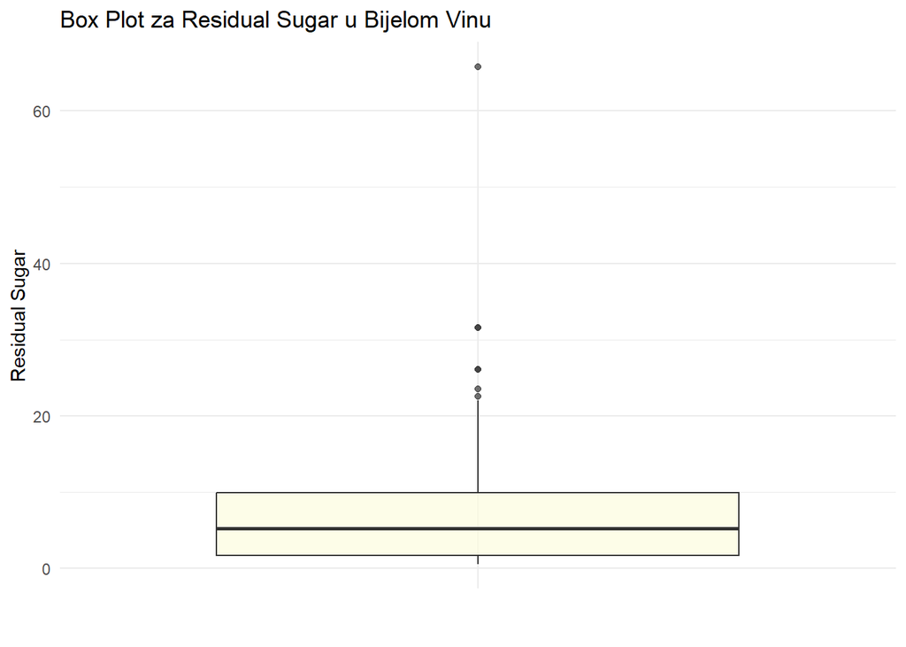

```r
boxplot_white
```

## Izračun korelacije varijabli za crveno i bijelo vino

```r
# Izračun korelacije za crveno vino
cor_red <- cor(winequality_red)

# Izračun korelacije za bijelo vino
cor_white <- cor(winequality_white)

# Prikazivanje korelacije za crveno vino
print("Korelacija za crveno vino:")
```

```
## [1] "Korelacija za crveno vino:"
```

```r
print(cor_red)
```

```
##                      fixed acidity volatile acidity citric acid residual sugar
## fixed acidity           1.00000000     -0.256130895  0.67170343    0.114776724
## volatile acidity       -0.25613089      1.000000000 -0.55249568    0.001917882
## citric acid             0.67170343     -0.552495685  1.00000000    0.143577162
## residual sugar          0.11477672      0.001917882  0.14357716    1.000000000
## chlorides               0.09370519      0.061297772  0.20382291    0.055609535
## free sulfur dioxide    -0.15379419     -0.010503827 -0.06097813    0.187048995
## total sulfur dioxide   -0.11318144      0.076470005  0.03553302    0.203027882
## density                 0.66804729      0.022026232  0.36494718    0.355283371
## pH                     -0.68297819      0.234937294 -0.54190414   -0.085652422
## sulphates               0.18300566     -0.260986685  0.31277004    0.005527121
## alcohol                -0.06166827     -0.202288027  0.10990325    0.042075437
## quality                 0.12405165     -0.390557780  0.22637251    0.013731637
##                         chlorides free sulfur dioxide total sulfur dioxide
## fixed acidity         0.093705186        -0.153794193          -0.11318144
## volatile acidity      0.061297772        -0.010503827           0.07647000
## citric acid           0.203822914        -0.060978129           0.03553302
## residual sugar        0.055609535         0.187048995           0.20302788
## chlorides             1.000000000         0.005562147           0.04740047
## free sulfur dioxide   0.005562147         1.000000000           0.66766645
## total sulfur dioxide  0.047400468         0.667666450           1.00000000
## density               0.200632327        -0.021945831           0.07126948
## pH                   -0.265026131         0.070377499          -0.06649456
## sulphates             0.371260481         0.051657572           0.04294684
## alcohol              -0.221140545        -0.069408354          -0.20565394
## quality              -0.128906560        -0.050656057          -0.18510029
##                          density          pH    sulphates     alcohol
## fixed acidity         0.66804729 -0.68297819  0.183005664 -0.06166827
## volatile acidity      0.02202623  0.23493729 -0.260986685 -0.20228803
## citric acid           0.36494718 -0.54190414  0.312770044  0.10990325
## residual sugar        0.35528337 -0.08565242  0.005527121  0.04207544
## chlorides             0.20063233 -0.26502613  0.371260481 -0.22114054
## free sulfur dioxide  -0.02194583  0.07037750  0.051657572 -0.06940835
## total sulfur dioxide  0.07126948 -0.06649456  0.042946836 -0.20565394
## density               1.00000000 -0.34169933  0.148506412 -0.49617977
## pH                   -0.34169933  1.00000000 -0.196647602  0.20563251
## sulphates             0.14850641 -0.19664760  1.000000000  0.09359475
## alcohol              -0.49617977  0.20563251  0.093594750  1.00000000
## quality              -0.17491923 -0.05773139  0.251397079  0.47616632
##                          quality
## fixed acidity         0.12405165
## volatile acidity     -0.39055778
## citric acid           0.22637251
## residual sugar        0.01373164
## chlorides            -0.12890656
## free sulfur dioxide  -0.05065606
## total sulfur dioxide -0.18510029
## density              -0.17491923
## pH                   -0.05773139
## sulphates             0.25139708
## alcohol               0.47616632
## quality               1.00000000
```

```r
# Prikazivanje korelacije za bijelo vino
print("Korelacija za bijelo vino:")
```

```
## [1] "Korelacija za bijelo vino:"
```

```r
print(cor_white)
```

```
##                      fixed acidity volatile acidity  citric acid residual sugar
## fixed acidity           1.00000000      -0.02269729  0.289180698     0.08902070
## volatile acidity       -0.02269729       1.00000000 -0.149471811     0.06428606
## citric acid             0.28918070      -0.14947181  1.000000000     0.09421162
## residual sugar          0.08902070       0.06428606  0.094211624     1.00000000
## chlorides               0.02308564       0.07051157  0.114364448     0.08868454
## free sulfur dioxide    -0.04939586      -0.09701194  0.094077221     0.29909835
## total sulfur dioxide    0.09106976       0.08926050  0.121130798     0.40143931
## density                 0.26533101       0.02711385  0.149502571     0.83896645
## pH                     -0.42585829      -0.03191537 -0.163748211    -0.19413345
## sulphates              -0.01714299      -0.03572815  0.062330940    -0.02666437
## alcohol                -0.12088112       0.06771794 -0.075728730    -0.45063122
## quality                -0.11366283      -0.19472297 -0.009209091    -0.09757683
##                        chlorides free sulfur dioxide total sulfur dioxide
## fixed acidity         0.02308564       -0.0493958591          0.091069756
## volatile acidity      0.07051157       -0.0970119393          0.089260504
## citric acid           0.11436445        0.0940772210          0.121130798
## residual sugar        0.08868454        0.2990983537          0.401439311
## chlorides             1.00000000        0.1013923521          0.198910300
## free sulfur dioxide   0.10139235        1.0000000000          0.615500965
## total sulfur dioxide  0.19891030        0.6155009650          1.000000000
## density               0.25721132        0.2942104109          0.529881324
## pH                   -0.09043946       -0.0006177961          0.002320972
## sulphates             0.01676288        0.0592172458          0.134562367
## alcohol              -0.36018871       -0.2501039415         -0.448892102
## quality              -0.20993441        0.0081580671         -0.174737218
##                          density            pH   sulphates     alcohol
## fixed acidity         0.26533101 -0.4258582910 -0.01714299 -0.12088112
## volatile acidity      0.02711385 -0.0319153683 -0.03572815  0.06771794
## citric acid           0.14950257 -0.1637482114  0.06233094 -0.07572873
## residual sugar        0.83896645 -0.1941334540 -0.02666437 -0.45063122
## chlorides             0.25721132 -0.0904394560  0.01676288 -0.36018871
## free sulfur dioxide   0.29421041 -0.0006177961  0.05921725 -0.25010394
## total sulfur dioxide  0.52988132  0.0023209718  0.13456237 -0.44889210
## density               1.00000000 -0.0935914935  0.07449315 -0.78013762
## pH                   -0.09359149  1.0000000000  0.15595150  0.12143210
## sulphates             0.07449315  0.1559514973  1.00000000 -0.01743277
## alcohol              -0.78013762  0.1214320987 -0.01743277  1.00000000
## quality              -0.30712331  0.0994272457  0.05367788  0.43557472
##                           quality
## fixed acidity        -0.113662831
## volatile acidity     -0.194722969
## citric acid          -0.009209091
## residual sugar       -0.097576829
## chlorides            -0.209934411
## free sulfur dioxide   0.008158067
## total sulfur dioxide -0.174737218
## density              -0.307123313
## pH                    0.099427246
## sulphates             0.053677877
## alcohol               0.435574715
## quality               1.000000000
```

```r
# Definiranje DataFrame objekata za korelaciju
cor_data_red <- as.data.frame(as.table(cor_red))
cor_data_white <- as.data.frame(as.table(cor_white))

# Promjena imena stupaca
names(cor_data_red) <- c("Var1", "Var2", "Freq")
names(cor_data_white) <- c("Var1", "Var2", "Freq")
```

## Grafički prikaz korelacije između varijabli za crveno i bijelo vino

Korelacijski koeficijent mjeri stupanj linearnog odnosa između dviju varijabli. Ako je korelacijski koeficijent bliži 1 (bilo pozitivnoj ili negativnoj vrijednosti), to ukazuje na jači linearni odnos između varijabli.

1. Korelacijski koeficijent blizu 1 ukazuje na pozitivnu linearnu korelaciju, što znači da kako jedna varijabla raste, tako raste i druga.
2. Korelacijski koeficijent blizu -1 ukazuje na negativnu linearnu korelaciju, što znači da kako jedna varijabla raste, druga opada.
3. Korelacijski koeficijent blizu 0 ukazuje na slabu ili nikakvu linearnu korelaciju između varijabli.

Dakle, iz prikaza za crveno vino može se zaključiti da postoji pozitivna linearna povezanost između varijabli:

```
      density - fixed acidity
      citric acid - fixed acidity
      total sulfur dioxide - free sulfur dioxide
```

A za negativnu linearnu povezanost:

```
      pH - fixed acidity
      citrix acid - volatile acidity
      pH - citrix acid
```

[NAPOMENA] - na grafu su označene vrijednosti samo za slučajeve gdje je korelacija veća od 0,5 ili manja od -0,5.

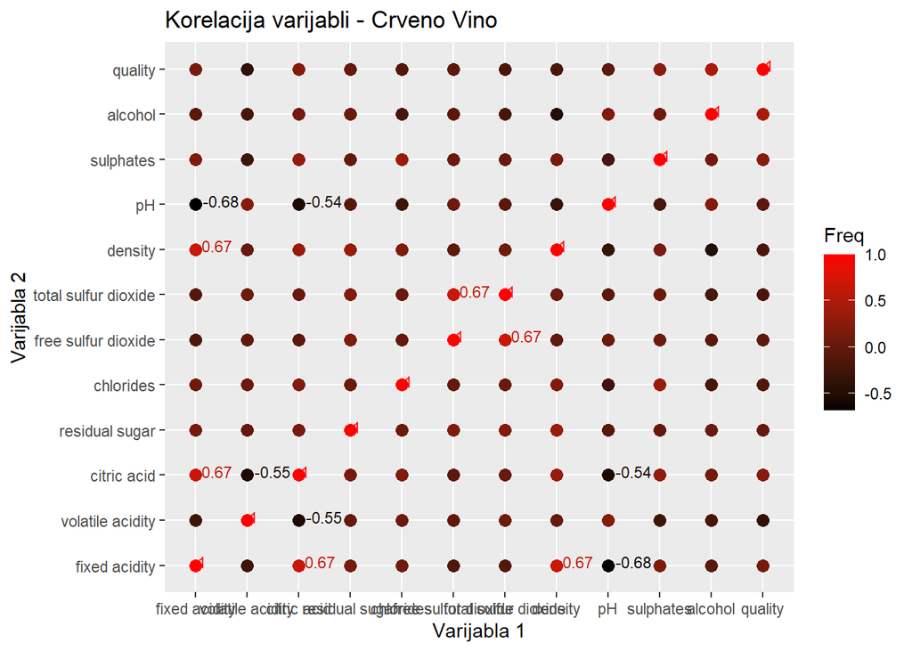

```r
# Stvaranje točkastog grafikona za crveno vino s promijenjenom širinom
ggplot(cor_data_red, aes(x = Var1, y = Var2, color = Freq, label = ifelse(abs(Freq) > 0.5, round(Freq, 2), ""))) +
  geom_point(size = 3) +
  geom_text(aes(label=ifelse(abs(Freq) > 0.5, round(Freq, 2), "")), hjust=-0.2, vjust=0.2, size=3) +
  scale_color_gradient(low = "black", high = "red") +
  labs(title = "Korelacija varijabli - Crveno Vino",
       x = "Varijabla 1",
       y = "Varijabla 2")
```

```r
ggsave("correlation_red.png", width = 15)
```

Što se tiče bijelog vina može se zaključiti da postoji pozitivna linearna povezanost između varijabli:

```
      density - residual sugar
      density - total sulfur dioxide
      total sulfur dioxide - free sulfur dioxide
```

A za negativnu linearnu povezanost:

```
     alcohol - density
```

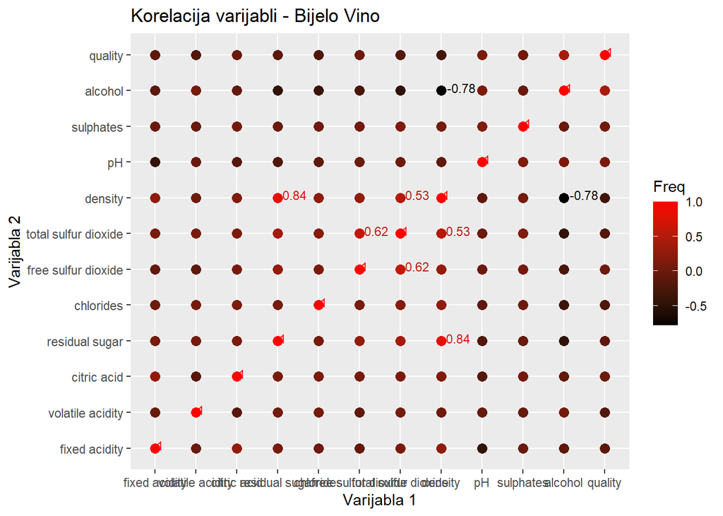

```r
# Stvaranje točkastog grafikona za bijelo vino s promijenjenom širinom
ggplot(cor_data_white, aes(x = Var1, y = Var2, color = Freq, label = ifelse(abs(Freq) > 0.5, round(Freq, 2), ""))) +
  geom_point(size = 3) +
  geom_text(aes(label=ifelse(abs(Freq) > 0.5, round(Freq, 2), "")), hjust=-0.2, vjust=0.2, size=3) +
  scale_color_gradient(low = "black", high = "red") +
  labs(title = "Korelacija varijabli - Bijelo Vino",
       x = "Varijabla 1",
       y = "Varijabla 2")
```

```r
# Spremanje grafova u datoteke
ggsave("correlation_white.png", width = 15)
```

## T-test Usporedba koncentracije sulfata i pH vrijednosti

### Usporedba koncentracije sulfata:

**Jasnoća hipoteza**: Testiramo da li postoji razlika u prosječnoj koncentraciji sulfata između crvenog i bijelog vina.

**Nulta hipoteza (H0)**: Prosječna koncentracija sulfata u crvenom vinu jednaka je prosječnoj koncentraciji sulfata u bijelom vinu (μ_crveno = μ_bijelo).

**Alternativna hipoteza (H1)**: Prosječna koncentracija sulfata u crvenom vinu nije jednaka prosječnoj koncentraciji sulfata u bijelom vinu (μ_crveno ≠ μ_bijelo).

**Interpretacija rezultata**: Dobiveni rezultati t-testa pokazuju statistički značajnu razliku (p-vrijednost < 0.05) u prosječnoj koncentraciji sulfata između crvenog i bijelog vina. Prosječna koncentracija sulfata u crvenom vinu (0.658 g/L) statistički je značajno veća od prosječne koncentracije sulfata u bijelom vinu (0.490 g/L). Ovo može ukazivati na razlike u proizvodnom procesu ili sastavu grožđa između crvenog i bijelog vina.

```r
# Provjera normalnosti podataka pomoću Shapiro-Wilk testa
shapiro_test_red <- shapiro.test(winequality_red$sulphates)
shapiro_test_white <- shapiro.test(winequality_white$sulphates)

# Ispis rezultata testiranja
print("Rezultat Shapiro-Wilk testa za crveno vino:")
```

```
## [1] "Rezultat Shapiro-Wilk testa za crveno vino:"
```

```r
print(shapiro_test_red)
```

```
##
##  Shapiro-Wilk normality test
##
## data:  winequality_red$sulphates
## W = 0.83304, p-value < 2.2e-16
```

```r
print("Rezultat Shapiro-Wilk testa za bijelo vino:")
```

```
## [1] "Rezultat Shapiro-Wilk testa za bijelo vino:"
```

```r
print(shapiro_test_white)
```

```
##
##  Shapiro-Wilk normality test
##
## data:  winequality_white$sulphates
## W = 0.95161, p-value < 2.2e-16
```

Testna statistika (W): Testna statistika (W) u ovom slučaju iznosi 6509961.

P-vrijednost: P-vrijednost koju dobivate (< 2.2e-16) sugerira da postoji iznimno mala vjerojatnost da se razlika između srednjih vrijednosti koncentracije sulfata u crvenom i bijelom vinu može pripisati slučajnosti. Stoga je p-vrijednost vrlo niska, što znači da su rezultati statistički značajni.

**Alternativna hipoteza**: Alternativna hipoteza, koja kaže da stvarna promjena mjesta (true location shift) nije jednaka 0, sugerira da postoji značajna razlika između srednjih vrijednosti koncentracije sulfata u crvenom i bijelom vinu. Znači odbacuje se H0 hipoteza i prihvaća se H1 hipoteza.

```r
# Izvođenje Wilcoxonovog rang-sum testa (Mann-Whitney U test)
wilcox_test <- wilcox.test(winequality_red$sulphates, winequality_white$sulphates)
print("Rezultat Wilcoxonovog rang-sum testa:")
```

```
## [1] "Rezultat Wilcoxonovog rang-sum testa:"
```

```r
print(wilcox_test)
```

```
##
##  Wilcoxon rank sum test with continuity correction
##
## data:  winequality_red$sulphates and winequality_white$sulphates
## W = 6509961, p-value < 2.2e-16
## alternative hypothesis: true location shift is not equal to 0
```

[figure not shown]

```r
# Q-Q dijagram za crveno vino
qqnorm(winequality_red$sulphates)
qqline(winequality_red$sulphates, col = "red")

# Dodavanje naslova i oznaka osi
title(main = "Q-Q Dijagram za Koncentraciju Sulfata - Crveno Vino")
xlabel <- expression("Teoretski kvantili")
ylabel <- expression("Opservirani kvantili")
title(xlab = xlabel, ylab = ylabel)
```

[figure not shown]

```r
# Q-Q dijagram za bijelo vino
qqnorm(winequality_white$sulphates)
qqline(winequality_white$sulphates, col = "blue")

# Dodavanje naslova i oznaka osi
title(main = "Q-Q Dijagram za Koncentraciju Sulfata - Bijelo Vino")
xlabel <- expression("Teoretski kvantili")
ylabel <- expression("Opservirani kvantili")
title(xlab = xlabel, ylab = ylabel)
```

```r
# T-test za usporedbu prosječne koncentracije sulfata između crvenog i bijelog vina
t_test_sulphates <- t.test(winequality_red$sulphates, winequality_white$sulphates)
print("Rezultat t-testa za usporedbu prosječne koncentracije sulfata između crvenog i bijelog vina:")
```

```
## [1] "Rezultat t-testa za usporedbu prosječne koncentracije sulfata između crvenog i bijelog vina:"
```

```r
print(t_test_sulphates)
```

```
##
##  Welch Two Sample t-test
##
## data:  winequality_red$sulphates and winequality_white$sulphates
## t = 37.056, df = 2091, p-value < 2.2e-16
## alternative hypothesis: true difference in means is not equal to 0
## 95 percent confidence interval:
##  0.159395 0.177209
## sample estimates:
## mean of x mean of y
## 0.6581488 0.4898469
```

**Jasnoća hipoteza:** Testiramo da li postoji razlika u prosječnoj pH vrijednosti između crvenog i bijelog vina.

**Nulta hipoteza (H0):** Prosječna pH vrijednost crvenog vina jednaka je prosječnoj pH vrijednosti bijelog vina (μ_crveno = μ_bijelo).

**Alternativna hipoteza (H1):** Prosječna pH vrijednost crvenog vina nije jednaka prosječnoj pH vrijednosti bijelog vina (μ_crveno ≠ μ_bijelo).

**Interpretacija rezultata:*** Također, rezultati t-testa za pH vrijednost pokazuju nešto manju razliku nego u prethodnom primjeru ali i dalje statistički značajnu (p-vrijednost < 0.05) između crvenog i bijelog vina. Prosječna pH vrijednost crvenog vina (3.31) statistički je veća od prosječne pH vrijednosti bijelog vina (3.19). Ovo može ukazivati na različite kiselosti između crvenog i bijelog vina, što može biti važno za ukupni dojam okusa i senzorski profil vina. Znači odbacuje se H0 hipoteza i prihvaća se H1 hipoteza.

```r
# T-test na temelju varijable pH za crveno i bijelo vino
t_test_pH <- t.test(winequality_red$pH, winequality_white$pH)
print("Rezultat t-testa za varijablu 'pH':")
```

```
## [1] "Rezultat t-testa za varijablu 'pH':"
```

```r
print(t_test_pH)
```

```
##
##  Welch Two Sample t-test
##
## data:  winequality_red$pH and winequality_white$pH
## t = 27.775, df = 2667.1, p-value < 2.2e-16
## alternative hypothesis: true difference in means is not equal to 0
## 95 percent confidence interval:
##  0.1141740 0.1315191
## sample estimates:
## mean of x mean of y
##  3.311113  3.188267
```

## HI-kvadrat test za kvalitetu vina

H0 - Ne postoji povezanost između varijabli kvaliteta vina i ph vrijednost.

H1 - Postoji povezanost između varijabli kvaliteta vina i ph vrijednost

**Hi-kvadrat test za crveno vino**:

**Rezultat testa**: P-vrijednost je 1, što znači da nema statistički značajne veze između kvalitete vina i kategorizirane varijable pH za crveno vino.

**Interpretacija**: Na temelju rezultata hi-kvadrat testa, ne možemo odbaciti nultu hipotezu. To znači da kvaliteta crvenog vina nije statistički povezana s kategoriziranom pH vrijednošću.

**Hi-kvadrat test za bijelo vino**:

**Rezultat testa**: P-vrijednost je također 1, što ukazuje da nema statistički značajne veze između kvalitete vina i kategorizirane varijable pH za bijelo vino.

**Interpretacija**: Slično crvenom vinu, ni za bijelo vino ne možemo odbaciti nultu hipotezu. To znači da kvaliteta bijelog vina nije statistički povezana s kategoriziranom pH vrijednošću.

Ovi rezultati sugeriraju da kvaliteta vina (ocjena) nije povezana s kategoriziranom pH vrijednošću, barem u okviru ovog testiranja. To može ukazivati na to da pH nije ključan faktor koji određuje kvalitetu vina, ili da drugi čimbenici imaju veći utjecaj na konačnu ocjenu vina.

```r
#Izračun prosječne kvalitete vina za crveno i bijelo vino
avg_quality_red <- mean(winequality_red$quality)
avg_quality_white <- mean(winequality_white$quality)

# Hi-kvadrat test na temelju kvalitete vina i varijable pH za crveno i bijelo vino
# Prvo moramo kategorizirati pH vrijednosti, na primjer, na nisku, srednju i visoku kiselinu
bins <- c(0, 3, 7, 14)  # Definiramo intervale: [0, 3], (3, 7], (7, 14]
labels <- c("Niska", "Srednja", "Visoka")  # Dodjeljujemo oznake intervalima

# Kategoriziramo pH vrijednosti za crveno vino
winequality_red$pH_category <- cut(winequality_red$pH, bins, labels = labels)

# Kategoriziramo pH vrijednosti za bijelo vino
winequality_white$pH_category <- cut(winequality_white$pH, bins, labels = labels)

# Izračunaj prosječnu kvalitetu za svaku kategoriju pH za crveno vino
quality_pH_red <- aggregate(quality ~ pH_category, data = winequality_red, FUN = mean)

# Izračunaj prosječnu kvalitetu za svaku kategoriju pH za bijelo vino
quality_pH_white <- aggregate(quality ~ pH_category, data = winequality_white, FUN = mean)

# Hi-kvadrat test na temelju kvalitete vina i kategorizirane varijable pH za crveno vino
chisq_pH_red <- chisq.test(quality_pH_red$quality, quality_pH_red$pH_category)
print("Rezultat hi-kvadrat testa za kvalitetu vina i pH za crveno vino:")
```

```
## [1] "Rezultat hi-kvadrat testa za kvalitetu vina i pH za crveno vino:"
```

```r
print(chisq_pH_red)
```

```
##
##  Pearson's Chi-squared test with Yates' continuity correction
##
## data:  quality_pH_red$quality and quality_pH_red$pH_category
## X-squared = 0, df = 1, p-value = 1
```

```r
# Hi-kvadrat test na temelju kvalitete vina i kategorizirane varijable pH za bijelo vino
chisq_pH_white <- chisq.test(quality_pH_white$quality, quality_pH_white$pH_category)
print("Rezultat hi-kvadrat testa za kvalitetu vina i pH za bijelo vino:")
```

```
## [1] "Rezultat hi-kvadrat testa za kvalitetu vina i pH za bijelo vino:"
```

```r
print(chisq_pH_white)
```

```
##
##  Pearson's Chi-squared test with Yates' continuity correction
##
## data:  quality_pH_white$quality and quality_pH_white$pH_category
## X-squared = 0, df = 1, p-value = 1
```